# Updated Power Analysis — LDP FAIR Compliance Study

One-sided paired t-test, n = 19 pairs, α = 0.05

Author

Jason Pither

Published

April 30, 2026

## Purpose

This document provides a corrected power analysis for the LDP FAIR compliance study. The original power analysis in the pre-registration used `pwr::pwr.t.test(n = 21, ...)` from the `pwr` package, and was not properly implemented. The analysis below is implemented entirely in base R using the non-central *t*-distribution, requires no additional packages, and is fully reproducible.

Two updates relative to the pre-registered analysis are incorporated:

1. **Corrected sample size:** Following post-hoc corrections (documented in the `LDP_find-articles` repository addendum), the final sample is n = **19** matched pairs, not 21.
2. **Broader parameterisation:** Power is evaluated across a range of plausible within-pair difference standard deviations (σ<sub>D</sub>) and Cohen’s *d* values, and the relationship between σ<sub>D</sub>, individual rater score variability, and inter-rater reliability (ICC) is made explicit.

## Background: the FAIR scoring rubric and the outcome variable

Each publication is scored by **k = 4** independent raters using the standardised FAIR compliance checklist. The rubric assigns a maximum of 1 point to each of the four FAIR letters (Findable, Accessible, Interoperable, Reusable), giving a composite score in [0, 4]:

| FAIR component | Possible values | Maximum |
| --- | --- | --- |
| **Findable** | 0 (absent/broken), 0.5 (unstructured), 1 (structured + working pointer) | 1 |
| **Accessible** | 0 or 1 (binary) | 1 |
| **Interoperable** | 0 or 1 (binary) | 1 |
| **Reusable** | 5 sub-items × 0.2 each (0 to 1 in steps of 0.2) | 1 |
| **Total** |  | **4** |

The **primary outcome** for each publication is the arithmetic mean of the four raters’ composite scores — a quasi-continuous value in [0, 4]. The paired difference for pair *i* is:

$$D_i = \bar{X}^{\text{LDP}}_i - \bar{X}^{\text{Comp}}_i$$

where $\bar{X}_i = \tfrac{1}{4}\sum_{j=1}^{4} X_{ij}$ is the mean of the four raters’ scores for publication *i*.

## Statistical framework

### Hypotheses

$$H_0: \mu_D = 0 \qquad H_a: \mu_D > 0$$

The test statistic is $t = \bar{D} \,/\, (s_D / \sqrt{n})$, compared to a one-sided critical value from the $t_{n-1}$ distribution at $\alpha = 0.05$.

### Cohen’s *d* for the paired design

Cohen’s *d* for the paired t-test (sometimes denoted *d*<sub>z</sub>) is:

$$d = \frac{\mu_D}{\sigma_D}$$

where:

- $\mu_D$ = the expected within-pair difference in mean FAIR scores (LDP minus comparator)
- $\sigma_D$ = the standard deviation of those within-pair differences

Given Cohen’s *d* and a sample size *n*, the minimum detectable mean difference (in score units on the 0–4 scale) is:

$$\mu_D^{\min} = d \times \sigma_D$$

### Power calculation

Power for the one-sided paired t-test is:

$$\text{Power} = P\!\left(T > t_{1-\alpha,\, n-1} \;\Big|\; T \sim t_{n-1,\, \lambda}\right)$$

where $\lambda = d\sqrt{n}$ is the non-centrality parameter and $t_{1-\alpha,\, n-1}$ is the $(1-\alpha)$ quantile of the central *t* distribution with $n-1$ degrees of freedom. This is computed in base R as:

```r
power_paired <- function(n, d, alpha = 0.05) {
  t_crit <- qt(1 - alpha, df = n - 1)
  ncp    <- d * sqrt(n)
  pt(t_crit, df = n - 1, ncp = ncp, lower.tail = FALSE)
}
```

```r
# Power for one-sided paired t-test using non-central t distribution
power_paired <- function(n, d, alpha = 0.05) {
  t_crit <- qt(1 - alpha, df = n - 1)
  ncp    <- d * sqrt(n)
  pt(t_crit, df = n - 1, ncp = ncp, lower.tail = FALSE)
}

# Minimum detectable Cohen's d for a given power (bisection search)
find_d <- function(n, target_power, alpha = 0.05, lo = 0, hi = 5, tol = 1e-8) {
  for (i in seq_len(200)) {
    mid <- (lo + hi) / 2
    p   <- power_paired(n, mid, alpha)
    if (abs(p - target_power) < tol) break
    if (p < target_power) lo <- mid else hi <- mid
  }
  mid
}
```

## Section A — Power across a range of Cohen’s *d* values

```r
n    <- 19
d_vals <- c(0.2, 0.3, 0.4, 0.5, 0.6, 0.7, 0.8, 1.0, 1.2)

pow_vec <- sapply(d_vals, power_paired, n = n)

power_df <- data.frame(
  `Cohen's d`   = d_vals,
  `Power (n=19)` = round(pow_vec, 3),
  check.names = FALSE
)
```

```r
knitr::kable(power_df, align = c("c", "c")) |>
  kableExtra::kable_styling(full_width = FALSE) |>
  kableExtra::row_spec(which(power_df[["Power (n=19)"]] >= 0.80), bold = TRUE,
                       background = "#D5F5E3")
```

Table 1: Statistical power of the one-sided paired t-test (α = 0.05, n = 19 pairs) for a range of Cohen’s *d* values. Power values ≥ 0.80 are highlighted.

| Cohen's d | Power (n=19) |
| --- | --- |
| 0.2 | 0.210 |
| 0.3 | 0.350 |
| 0.4 | 0.513 |
| 0.5 | 0.674 |
| 0.6 | 0.808 |
| 0.7 | 0.901 |
| 0.8 | 0.956 |
| 1.0 | 0.995 |
| 1.2 | 1.000 |

## Section B — Minimum detectable effect size across σ<sub>D</sub> values

The minimum detectable mean FAIR score difference (on the 0–4 scale) depends on both Cohen’s *d* and the within-pair difference standard deviation σ<sub>D</sub>:

$$\mu_D^{\min} = d^* \times \sigma_D$$

The table below reports $d^*$ (minimum Cohen’s *d* for 80% and 90% power) and the corresponding minimum detectable mean score difference for five plausible values of σ<sub>D</sub>.

```r
sigma_D_vals <- c(0.50, 0.75, 1.00, 1.25, 1.50)

d_80 <- find_d(n = 19, target_power = 0.80)
d_90 <- find_d(n = 19, target_power = 0.90)

mde_df <- data.frame(
  `σ_D`                    = sigma_D_vals,
  `Min. detectable diff. (80% power)` = round(d_80 * sigma_D_vals, 3),
  `Min. detectable diff. (90% power)` = round(d_90 * sigma_D_vals, 3),
  check.names = FALSE
)

# Prepend the d* row header info as a note
attr(mde_df, "note") <- sprintf(
  "Minimum detectable Cohen's d: 80%% power → d* = %.3f; 90%% power → d* = %.3f",
  d_80, d_90
)

knitr::kable(mde_df, align = c("c", "c", "c")) |>
  kableExtra::kable_styling(full_width = FALSE) |>
  kableExtra::footnote(
    general = sprintf(
      "Minimum detectable Cohen's d (n = 19, α = 0.05, one-sided): 80%% power → d* = %.3f; 90%% power → d* = %.3f.",
      d_80, d_90
    ),
    general_title = ""
  )
```

Table 2: Minimum detectable Cohen’s *d* and mean FAIR score difference (0–4 scale) at 80% and 90% power (one-sided paired t-test, α = 0.05, n = 19 pairs), across a range of within-pair difference standard deviations σ<sub>D</sub>.

| σ_D | Min. detectable diff. (80% power) | Min. detectable diff. (90% power) |
| --- | --- | --- |
| 0.50 | 0.297 | 0.349 |
| 0.75 | 0.445 | 0.524 |
| 1.00 | 0.593 | 0.698 |
| 1.25 | 0.741 | 0.873 |
| 1.50 | 0.890 | 1.047 |

Minimum detectable Cohen's d (n = 19, α = 0.05, one-sided): 80% power → d* = 0.593; 90% power → d* = 0.698.

## Section C — How σ<sub>D</sub> relates to individual rater score variability and ICC

The within-pair difference standard deviation σ<sub>D</sub> can be expressed in terms of observable quantities:

$$\sigma_D = \sigma \cdot \sqrt{2} \cdot \sqrt{\text{ICC} + \frac{1 - \text{ICC}}{k}}$$

where:

- $\sigma$ = standard deviation of a **single rater’s** composite FAIR score across all publications (scale: 0–4)
- ICC = intraclass correlation coefficient (two-way mixed, absolute agreement, average measures, *k* = 4 raters) — the proportion of total score variance attributable to between-publication differences
- $k$ = number of raters (here, *k* = 4)

**Derivation.** Under the standard one-way ICC variance-components model, $X_{ij} = \mu_i + \varepsilon_{ij}$, where $\mu_i \sim \mathcal{N}(\mu,\, \sigma^2_{\text{between}})$ and $\varepsilon_{ij} \sim \mathcal{N}(0,\, \sigma^2_{\text{within}})$:

$$\text{Var}(\bar{X}_i) = \sigma^2_{\text{between}} + \frac{\sigma^2_{\text{within}}}{k}
= \sigma^2 \left[\text{ICC} + \frac{1-\text{ICC}}{k}\right]$$

where $\sigma^2 = \sigma^2_{\text{between}} + \sigma^2_{\text{within}}$ is the total variance of a single rating. Assuming LDP and comparator scores within a pair are independent:

$$\sigma^2_D = 2\,\text{Var}(\bar{X}_i) = 2\,\sigma^2\left[\text{ICC} +
\frac{1-\text{ICC}}{k}\right]$$

As ICC → 1 (all variance between publications, raters agree perfectly), $\sigma_D \to \sigma\sqrt{2}$. As ICC → 0 (all variance is rater noise, averaging over raters is maximally beneficial), $\sigma_D \to \sigma\sqrt{2/k} = \sigma/\sqrt{2}$ for $k = 4$.

```r
sigma_vals <- c(0.6, 0.8, 1.0, 1.2)
icc_vals   <- c(0.40, 0.50, 0.60, 0.70, 0.80)
k          <- 4

rows <- lapply(sigma_vals, function(s) {
  vals <- sapply(icc_vals, function(icc) {
    sd_D <- s * sqrt(2) * sqrt(icc + (1 - icc) / k)
    mde  <- d_80 * sd_D
    sprintf("%.2f (%.2f)", sd_D, mde)
  })
  c(sigma = as.character(s), vals)
})

sigma_D_table <- as.data.frame(do.call(rbind, rows), stringsAsFactors = FALSE)
colnames(sigma_D_table) <- c("σ (single rater)",
                              paste0("ICC = ", icc_vals))

knitr::kable(sigma_D_table, align = rep("c", ncol(sigma_D_table))) |>
  kableExtra::kable_styling(full_width = FALSE) |>
  kableExtra::footnote(
    general = paste0(
      "Each cell shows σ_D (SD of within-pair differences in mean scores) with the minimum ",
      "detectable mean FAIR score difference at 80% power in parentheses. ",
      sprintf("d* = %.3f for 80%% power (n = 19, α = 0.05, one-sided).", d_80)
    ),
    general_title = ""
  )
```

Table 3: Implied σ<sub>D</sub> (SD of within-pair differences in mean FAIR scores) for combinations of single-rater score SD (σ) and ICC, with k = 4 raters. Values in parentheses indicate the minimum detectable mean FAIR score difference at 80% power (n = 19).

| σ (single rater) | ICC = 0.4 | ICC = 0.5 | ICC = 0.6 | ICC = 0.7 | ICC = 0.8 |
| --- | --- | --- | --- | --- | --- |
| 0.6 | 0.63 (0.37) | 0.67 (0.40) | 0.71 (0.42) | 0.75 (0.44) | 0.78 (0.46) |
| 0.8 | 0.84 (0.50) | 0.89 (0.53) | 0.95 (0.56) | 1.00 (0.59) | 1.04 (0.62) |
| 1 | 1.05 (0.62) | 1.12 (0.66) | 1.18 (0.70) | 1.24 (0.74) | 1.30 (0.77) |
| 1.2 | 1.26 (0.75) | 1.34 (0.80) | 1.42 (0.84) | 1.49 (0.89) | 1.56 (0.93) |

Each cell shows σ_D (SD of within-pair differences in mean scores) with the minimum detectable mean FAIR score difference at 80% power in parentheses. d* = 0.593 for 80% power (n = 19, α = 0.05, one-sided).

## Section D — Power across the full σ<sub>D</sub> × *d* grid

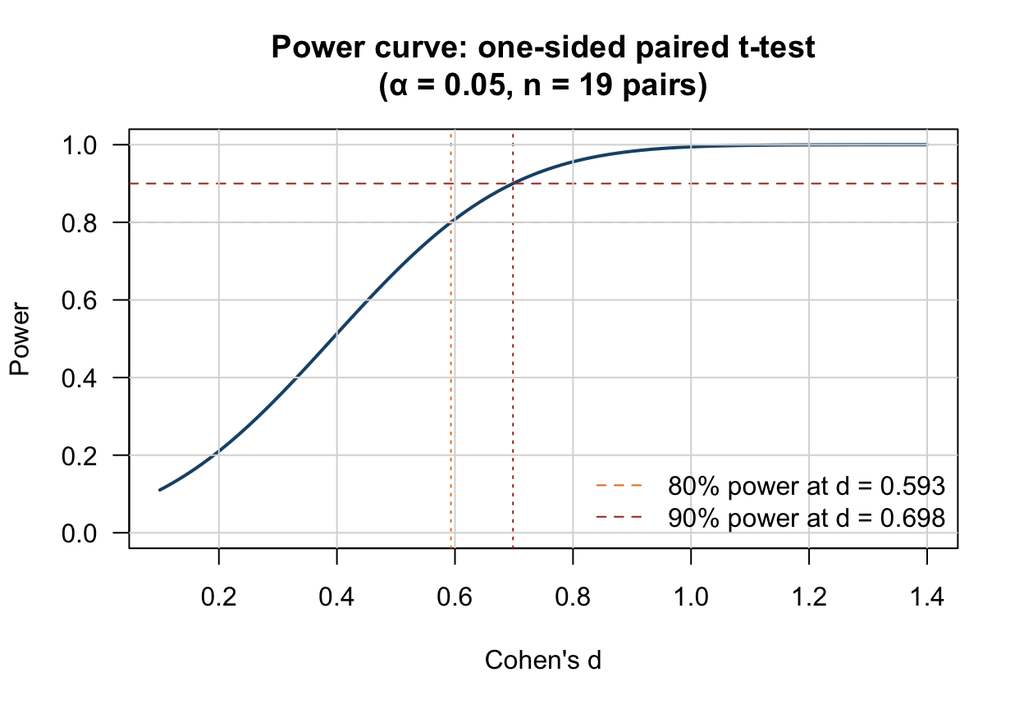

Figure 1: Statistical power of the one-sided paired t-test as a function of Cohen’s d (n = 19 pairs, α = 0.05, one-sided). The power curve is parameterised by Cohen’s d (= μ_D / σ_D) and therefore does not assume a specific value of σ_D (the SD of within-pair mean FAIR score differences, scale 0–4). Vertical dotted lines mark the minimum detectable Cohen’s d: d* = 0.593 at 80% power and d* = 0.698 at 90% power. To convert d* to score units on the 0–4 scale, multiply by σ_D. Across the σ_D range explored in Sections B–C (0.50–1.50), these thresholds correspond to minimum detectable mean differences of 0.30–0.89 score points (80% power) and 0.35–1.05 score points (90% power).

```r
d_seq  <- seq(0.1, 1.4, by = 0.01)
pow_seq <- sapply(d_seq, power_paired, n = 19)

plot(d_seq, pow_seq, type = "l", lwd = 2, col = "#1A5276",
     xlab = "Cohen's d", ylab = "Power",
     main = "Power curve: one-sided paired t-test\n(α = 0.05, n = 19 pairs)",
     ylim = c(0, 1), las = 1)
abline(h = c(0.80, 0.90), lty = 2, col = c("#E67E22", "#A93226"))
abline(v = c(d_80, d_90), lty = 3, col = c("#E67E22", "#A93226"))
grid(col = "grey85", lty = 1)
legend("bottomright",
       legend = c(
         sprintf("80%% power at d = %.3f", d_80),
         sprintf("90%% power at d = %.3f", d_90)
       ),
       lty = 2, col = c("#E67E22", "#A93226"), bty = "n")
```

The figure above is parameterised in Cohen’s *d* units. The figure below translates those thresholds into actual FAIR score units by expressing the minimum detectable mean difference as a function of σ<sub>D</sub>. Because MDE = *d** × σ<sub>D</sub> with *d** fixed by *n*, α, and power, the relationship is linear: the slope equals *d** and the intercept is zero. Larger σ<sub>D</sub> (more variable within-pair differences) requires a larger absolute effect to achieve the same power.

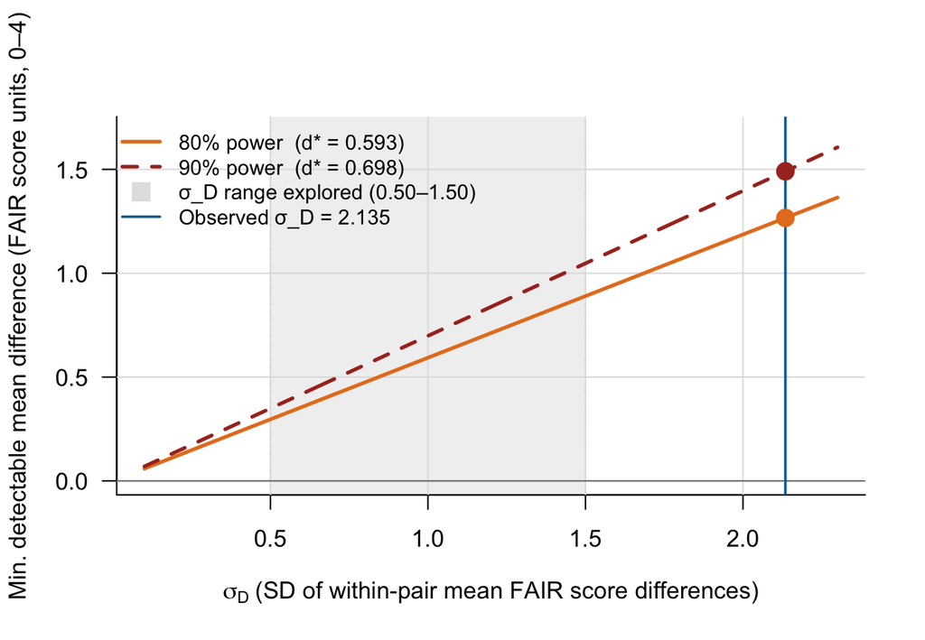

Figure 2: Minimum detectable mean FAIR score difference (MDE = d* × σ_D) as a function of σ_D (SD of within-pair mean score differences), for 80% power (solid, d* = 0.593) and 90% power (dashed, d* = 0.698). The shaded band marks the σ_D range explored in Sections B–C (0.50–1.50). The vertical blue line shows the observed σ_D from the study (if available), with filled circles marking the corresponding MDE at each power level. n = 19 pairs, α = 0.05, one-sided.

```r
# ── Observed σ_D from the study (optional; graceful fallback if file absent) ──
sigma_D_obs <- tryCatch(
  sd(readr::read_csv(
    "../../LDP_analysis/data/data_processed/pairs_data.csv",
    show_col_types = FALSE
  )$D),
  error = function(e) NULL
)

# ── Axis limits: extend x to include observed σ_D if it exceeds 2.0 ──────────
x_max       <- if (!is.null(sigma_D_obs)) max(2.0, ceiling(sigma_D_obs * 5) / 5 + 0.1) else 2.0
sigma_D_seq <- seq(0.10, x_max, length.out = 500)
mde_80      <- d_80 * sigma_D_seq
mde_90      <- d_90 * sigma_D_seq

# ── Base plot (empty frame first so polygon is drawn under lines) ─────────────
plot(sigma_D_seq, mde_80, type = "n",
     xlab = expression(sigma[D]~"(SD of within-pair mean FAIR score differences)"),
     ylab = "Min. detectable mean difference (FAIR score units, 0–4)",
     ylim = c(0, d_90 * x_max * 1.05),
     xlim = c(0.1, x_max),
     las  = 1, bty = "l")

# ── Shaded band for explored σ_D range ───────────────────────────────────────
polygon(c(0.50, 1.50, 1.50, 0.50),
        c(-1, -1, 99, 99),
        col = adjustcolor("grey60", alpha.f = 0.15), border = NA)
abline(v = c(0.50, 1.50), lty = 3, col = "grey55")

# ── Grid and axes ─────────────────────────────────────────────────────────────
grid(col = "grey88", lty = 1)
abline(h = 0, col = "grey50")

# ── MDE lines ─────────────────────────────────────────────────────────────────
lines(sigma_D_seq, mde_80, lwd = 2.5, col = "#E67E22")
lines(sigma_D_seq, mde_90, lwd = 2.5, col = "#A93226", lty = 2)

# ── Observed σ_D annotation (conditional) ────────────────────────────────────
leg_text <- c(
  sprintf("80%% power  (d* = %.3f)", d_80),
  sprintf("90%% power  (d* = %.3f)", d_90),
  "σ_D range explored (0.50–1.50)"
)
leg_lty <- c(1, 2, NA)
leg_lwd <- c(2.5, 2.5, NA)
leg_col <- c("#E67E22", "#A93226", NA)
leg_pch <- c(NA, NA, 22)   # filled square swatch for shaded band
leg_pt_bg <- c(NA, NA, adjustcolor("grey60", 0.3))
leg_pt_cex <- c(NA, NA, 2)

if (!is.null(sigma_D_obs)) {
  abline(v   = sigma_D_obs, lty = 1, col = "#1A6FA0", lwd = 1.8)
  points(sigma_D_obs, d_80 * sigma_D_obs, pch = 19, col = "#E67E22", cex = 1.6)
  points(sigma_D_obs, d_90 * sigma_D_obs, pch = 19, col = "#A93226", cex = 1.6)
  leg_text <- c(leg_text,
                sprintf("Observed σ_D = %.3f", sigma_D_obs))
  leg_lty  <- c(leg_lty,  1)
  leg_lwd  <- c(leg_lwd,  1.8)
  leg_col  <- c(leg_col,  "#1A6FA0")
  leg_pch  <- c(leg_pch,  NA)
  leg_pt_bg  <- c(leg_pt_bg, NA)
  leg_pt_cex <- c(leg_pt_cex, NA)
}

legend("topleft",
       legend  = leg_text,
       lty     = leg_lty,
       lwd     = leg_lwd,
       col     = leg_col,
       pch     = leg_pch,
       pt.bg   = leg_pt_bg,
       pt.cex  = leg_pt_cex,
       bty     = "n", cex = 0.88)
```

## Section E — Comparison with the pre-registered analysis (n = 21)

```r
d_80_n21 <- find_d(n = 21, target_power = 0.80)
d_90_n21 <- find_d(n = 21, target_power = 0.90)
d_80_n19 <- find_d(n = 19, target_power = 0.80)
d_90_n19 <- find_d(n = 19, target_power = 0.90)

sigma_compare <- c(0.85, 1.00)

comp_rows <- lapply(sigma_compare, function(s) {
  c(
    `σ_D` = as.character(s),
    `n=21, 80% power` = sprintf("%.3f (d* = %.3f)", d_80_n21 * s, d_80_n21),
    `n=21, 90% power` = sprintf("%.3f (d* = %.3f)", d_90_n21 * s, d_90_n21),
    `n=19, 80% power` = sprintf("%.3f (d* = %.3f)", d_80_n19 * s, d_80_n19),
    `n=19, 90% power` = sprintf("%.3f (d* = %.3f)", d_90_n19 * s, d_90_n19)
  )
})

comp_df <- as.data.frame(do.call(rbind, comp_rows), stringsAsFactors = FALSE)

knitr::kable(comp_df, align = rep("c", ncol(comp_df))) |>
  kableExtra::kable_styling(full_width = FALSE) |>
  kableExtra::footnote(
    general = "Each cell shows the minimum detectable mean FAIR score difference (0–4 scale) with the corresponding Cohen's d* in parentheses.",
    general_title = ""
  )
```

Table 4: Comparison of minimum detectable mean FAIR score differences between the pre-registered analysis (n = 21) and the corrected analysis (n = 19), at 80% and 90% power, for two assumed values of σ<sub>D</sub>.

| σ_D | n=21, 80% power | n=21, 90% power | n=19, 80% power | n=19, 90% power |
| --- | --- | --- | --- | --- |
| 0.85 | 0.478 (d* = 0.562) | 0.562 (d* = 0.662) | 0.504 (d* = 0.593) | 0.594 (d* = 0.698) |
| 1 | 0.562 (d* = 0.562) | 0.662 (d* = 0.662) | 0.593 (d* = 0.593) | 0.698 (d* = 0.698) |

Each cell shows the minimum detectable mean FAIR score difference (0–4 scale) with the corresponding Cohen's d* in parentheses.

The reduction from n = 21 to n = 19 pairs results in a modest increase in the minimum detectable effect size. With σ<sub>D</sub> = 1.0:

- **80% power threshold** increases from 0.56 (n = 21) to 0.59 (n = 19) score points (Cohen’s d: 0.562 → 0.593)
- **90% power threshold** increases from 0.66 (n = 21) to 0.70 (n = 19) score points (Cohen’s d: 0.662 → 0.698)

The study remains adequately powered to detect moderate-to-large effects (Cohen’s d ≥ 0.59) and underpowered for small effects (Cohen’s d < 0.4). The permutation test (sign-flip on paired differences) has power approaching that of the paired t-test under normality, so these estimates are approximately applicable to both primary and backup tests.